# Forecasting Monthly U.S. Restaurant and Bar Sales with STL Decomposition: Choosing the Training Window

Kevin Campoverde

2026-11-20

# 1 Introduction

In this section, we will introduce the purpose and the research question, and then preview the data and the forecasting method.

## 1.1 Rationale and Research Question

Food services and drinking establishments can use sales forecasts to guide staffing levels, inventory orders, and budget allocation. In the US, monthly sales in food services and drinking places from 2012 to 2025 roughly doubled. Additionally, sales rise and fall in a regular pattern within each year. For an accurate prediction, a forecast relies on historical monthly data to capture both long-term growth and recurring annual patterns. Splitting the data into training and testing sets allows us to measure the accuracy of the forecasting model, yet it is unknown how much of the past data to use for training. This decision matters because a sharp decline occurred from February 2020 to April 2020, when sales decreased by more than half. We assess three variations of the training data, two including observations before the drop and one covering the period after it.

In the previous report about weekly flu hospital admissions, we used four baseline forecasting models (moving average, naive, seasonal naive, and drift), mainly as a benchmark test. Due to the models’ inability to account for both the long-term trend and yearly seasonal pattern simultaneously, this report shifts to a time series decomposition approach that separates the data into a trend, a seasonal pattern, and random errors before forecasting. This allows the forecast to capture both the long-term upward growth and the repeating yearly pattern. The primary objective of this study is to assess which of the three training windows (the most recent 168, 96, or 60 months before the testing year) yields the lowest forecast error for monthly U.S. restaurant and bar sales for the 12 months from October 2025 to September 2026. Monthly U.S. sales for food services and drinking places are denoted by $y_t$, the variable of interest.

# 2 Materials

In this section, we will cover where the data comes from, how we obtained the data set, the variables, and the number of observations.

## 2.1 Data Collection

The dataset is the series “Retail Sales: Food Services and Drinking Places” (series ID MRTSSM722USN) from the U.S. Census Bureau via the Federal Reserve Bank of St. Louis (FRED) (Federal Reserve Bank of St. Louis, 2026). Every month, the U.S. Census Bureau conducts the Monthly Retail Trade Survey across approximately 13,000 retail and food services businesses with paid employees (U.S. Census Bureau, 2026). The total monthly sales (in millions of dollars) are collected from these responses. They are not seasonally adjusted, which preserves the seasonal pattern in the data. Recent months in this series can still be revised in later releases. For this reason, we saved a fixed copy of the data on November 17, 2026. The most recent month in this copy (September 2026) is an initial estimate.

## 2.2 Loading the Data Set

Every month from January 1992 to September 2026 (417 months) is included in the full dataset. Older observations may be less informative for predicting future values; thus, we restrict our sample to the 180 most recent months, starting in October 2011. This window provides 15 complete seasonal cycles of data, allowing evaluation of the periods before, during, and after the 2020 drop.

```r
# Read the data set directly from GitHub
url = "https://kc1008143.github.io/sta321/MRTSSM722USN.csv"
sales.all = read.csv(url, header = TRUE)
names(sales.all) = c("date", "sales")       # shorter column names
sales.all$date = as.Date(sales.all$date)    # store the month as a date
# Keep the 180 most recent months: October 2011 to September 2026
sales = sales.all[sales.all$date >= as.Date("2011-10-01") &
                  sales.all$date <= as.Date("2026-09-01"), ]
n = nrow(sales)                             # number of months used
```

## 2.3 Variables

The variables are listed below with their type and a brief description.

```r
# Table describing each variable
var_table = data.frame(
  Variable = c("Month", "Sales"),
  Type = c("Date (time index)", "Numerical (continuous) - time series"),
  Description = c("First day of the month the sales are for",
                  "Total sales of U.S. food services and drinking places that month, in millions of dollars, not seasonally adjusted")
)
kable(var_table, caption = "Table 1. Variables in the data set.")
```

Table 1. Variables in the data set.

| Variable | Type | Description |
| --- | --- | --- |
| Month | Date (time index) | First day of the month the sales are for |
| Sales | Numerical (continuous) - time series | Total sales of U.S. food services and drinking places that month, in millions of dollars, not seasonally adjusted |

In a time series, we evaluate a single variable, here monthly sales, over time, and the month gives the order of the observations.

## 2.4 Sample Size and Missing Values

Table 2 summarizes the number of months, the first and last months, missing values, and skipped months for the full file and for the window used in this report.

```r
# Number of months, first and last month, missing values, and skipped months
# skipped month = more than 31 days between two rows
sample.table = data.frame(
  Data = c("Full file", "Window used"),
  Months = c(nrow(sales.all), n),
  First.month = format(c(min(sales.all$date), min(sales$date)), "%b %Y"),
  Last.month = format(c(max(sales.all$date), max(sales$date)), "%b %Y"),
  Missing.values = c(sum(is.na(sales.all$sales)), sum(is.na(sales$sales))),
  Skipped.months = c(sum(diff(sales.all$date) > 31), sum(diff(sales$date) > 31))
)
kable(sample.table, col.names = c("Data", "Months", "First month", "Last month",
                                  "Missing values", "Skipped months"),
      caption = "Table 2. Number of months, first and last month, missing values, and skipped months.")
```

Table 2. Number of months, first and last month, missing values, and skipped months.

| Data | Months | First month | Last month | Missing values | Skipped months |
| --- | --- | --- | --- | --- | --- |
| Full file | 417 | Jan 1992 | Sep 2026 | 0 | 0 |
| Window used | 180 | Oct 2011 | Sep 2026 | 0 | 0 |

Table 2 provides a brief overview of the full file (417 months) and the 180-month window used in this report (October 2011 to September 2026). Because this window is simply a subset extracted directly from the full file, which has no missing values or skipped months, the window has none either. This means the observations are evenly spaced, with one for every month.

# 3 Exploratory Data Analysis

Before we build the forecasting models, we plot the series, summarize each year, and decompose the series to look for a trend, seasonality, changes in the size of the seasonal swings, and unusual periods. We then use these results to choose the forecasting model.

## 3.1 Time Series Plot

Figure 1 is the time series plot of the monthly sales over the 180-month window.

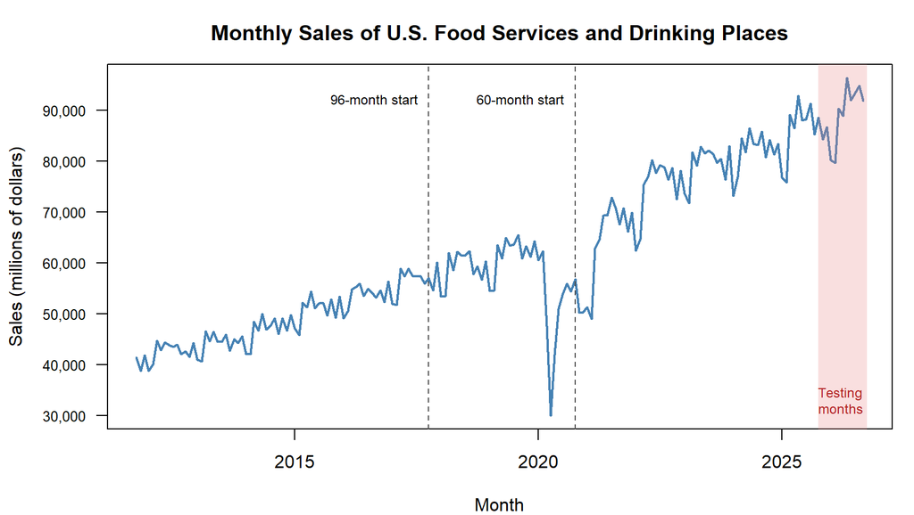

Figure 1. Monthly sales of U.S. food services and drinking places, October 2011 to September 2026 (millions of dollars, not seasonally adjusted). The dashed lines mark the start of the 96-month and 60-month training windows (the 168-month window starts at the beginning of the plot), and the shaded area marks the 12 testing months.

```r
# Time series plot of the 180 months
par(mar = c(4, 5, 3, 1))
plot(sales$date, sales$sales, type = "l", col = "steelblue", lwd = 2,
     xlab = "Month", ylab = "", yaxt = "n",
     main = "Monthly Sales of U.S. Food Services and Drinking Places")
# y-axis in steps of 10,000 with commas
axis(2, at = seq(30000, 100000, 10000), las = 1, cex.axis = 0.8,
     labels = format(seq(30000, 100000, 10000), big.mark = ",", scientific = FALSE))
mtext("Sales (millions of dollars)", side = 2, line = 3.8)
# Shaded testing year and dashed lines at the training window starts
rect(as.Date("2025-10-01"), 0, as.Date("2026-09-30"), 120000,
     col = rgb(0.9, 0.5, 0.5, 0.25), border = NA)
abline(v = as.Date(c("2017-10-01", "2020-10-01")), lty = 2, col = "gray30")
text(as.Date(c("2017-10-01", "2020-10-01")), 92000,
     c("96-month start", "60-month start"), pos = 2, cex = 0.75)
text(as.Date("2026-03-15"), 33000, "Testing\nmonths", cex = 0.75, col = "firebrick")
```

As shown in Figure 1, there appears to be an upward trend, with sales roughly doubling over the 15-year window. There are indications of a 12-month seasonal period, as the series repeats a similar pattern from year to year. Additionally, the seasonal swings appear substantially wider in recent years as sales increased. The most extreme deviation from the series’ behavior occurs between February 2020 and April 2020, at the start of the COVID-19 pandemic, with sales dropping from $62,258 million to $29,984 million (Table 3). Notably, this is the lowest monthly sales value recorded in the observation period. There was a large dip in sales during the winter of 2020–2021, shortly after a partial recovery, dropping to $48,958 million in February 2021 (Table 3). The series is not stationary, as it has both a trend and seasonality.

## 3.2 Yearly Summary and Seasonal Swings

To check whether the seasonal swings stay the same size or grow with the level of sales, Table 3 lists the average, the lowest and highest months, and the seasonal swing (highest month minus lowest month) of each year.

```r
# Yearly summary: average, lowest and highest month, and the seasonal swing
year = as.numeric(format(sales$date, "%Y"))
month.name.s = format(sales$date, "%b")   # abbreviated month names
# month with the lowest and highest sales of each year
low.month  = tapply(1:n, year, function(i) month.name.s[i][which.min(sales$sales[i])])
high.month = tapply(1:n, year, function(i) month.name.s[i][which.max(sales$sales[i])])
year.table = data.frame(
  Year = as.character(unique(year)),
  Months = as.vector(table(year)),
  Average = as.vector(tapply(sales$sales, year, mean)),
  Low = as.vector(tapply(sales$sales, year, min)),
  Low.month = as.vector(low.month),
  High = as.vector(tapply(sales$sales, year, max)),
  High.month = as.vector(high.month)
)
# swing = highest month - lowest month, also as % of the yearly average
year.table$Swing = year.table$High - year.table$Low
year.table$Swing.pct = 100 * year.table$Swing / year.table$Average
kable(year.table, digits = c(0, 0, 0, 0, 0, 0, 0, 0, 1), format.args = list(big.mark = ","),
      col.names = c("Year", "Months", "Average", "Lowest", "Lowest month",
                    "Highest", "Highest month", "Swing", "Swing (%)"),
      caption = "Table 3. Yearly summary of monthly sales. Average (monthly sales), Lowest, Highest, and Swing are in millions of dollars. Swing (%) is the swing as a percentage of the average. 2011 and 2026 are incomplete years.")
```

Table 3. Yearly summary of monthly sales. Average (monthly sales), Lowest, Highest, and Swing are in millions of dollars. Swing (%) is the swing as a percentage of the average. 2011 and 2026 are incomplete years.

| Year | Months | Average | Lowest | Lowest month | Highest | Highest month | Swing | Swing (%) |
| --- | --- | --- | --- | --- | --- | --- | --- | --- |
| 2011 | 3 | 40,668 | 38,777 | Nov | 41,873 | Dec | 3,096 | 7.6 |
| 2012 | 12 | 42,690 | 38,776 | Jan | 44,635 | Mar | 5,859 | 13.7 |
| 2013 | 12 | 44,291 | 40,643 | Feb | 46,587 | Mar | 5,944 | 13.4 |
| 2014 | 12 | 47,003 | 41,996 | Feb | 49,905 | May | 7,909 | 16.8 |
| 2015 | 12 | 50,891 | 45,761 | Feb | 54,310 | May | 8,549 | 16.8 |
| 2016 | 12 | 53,684 | 49,072 | Jan | 56,304 | Dec | 7,232 | 13.5 |
| 2017 | 12 | 56,512 | 51,695 | Feb | 60,014 | Dec | 8,319 | 14.7 |
| 2018 | 12 | 59,058 | 53,392 | Jan | 62,311 | Aug | 8,919 | 15.1 |
| 2019 | 12 | 61,677 | 54,505 | Jan | 65,393 | Aug | 10,888 | 17.7 |
| 2020 | 12 | 51,224 | 29,984 | Apr | 62,258 | Feb | 32,274 | 63.0 |
| 2021 | 12 | 65,325 | 48,958 | Feb | 72,848 | Jul | 23,890 | 36.6 |
| 2022 | 12 | 75,051 | 62,325 | Jan | 80,125 | May | 17,800 | 23.7 |
| 2023 | 12 | 79,427 | 71,752 | Feb | 82,897 | Dec | 11,145 | 14.0 |
| 2024 | 12 | 82,017 | 73,115 | Jan | 86,438 | May | 13,323 | 16.2 |
| 2025 | 12 | 86,061 | 75,757 | Feb | 92,764 | May | 17,007 | 19.8 |
| 2026 | 9 | 89,670 | 79,616 | Feb | 96,336 | May | 16,720 | 18.6 |

From 2012 to 2025, the relative swing (the swing as a percentage of the yearly average) remains within a narrow range (13.4% to 19.8%), excluding the 2020–2022 period. Average monthly sales roughly doubled, increasing from $42,690 million to $86,061 million, while the seasonal swing almost tripled, from $5,859 million to $17,007 million. Table 3 therefore indicates that seasonal swings grow with the level of sales rather than staying the same size. Thus, we choose the multiplicative model ($y_t = T_t \times S_t \times E_t$). It is worth noting that the large deviations in relative swings occur during the COVID-19 years (2020–2022), and 2020 and 2021 include the abrupt drops in spring 2020 and winter 2020–21.

Furthermore, excluding 2020, the trough month in each complete calendar year was either January or February. In 2020, April had the lowest sales of both the year and the entire window. The months with the highest sales were less consistent, going from March, May, and December in 2012–2017, to August in 2018–2019, and May in 2022, 2024, and 2025, with December in 2023 (excluding 2020 and 2021). This may indicate a slow shift in the seasonal pattern over time.

## 3.3 Classical Multiplicative Decomposition

Since the series appears multiplicative, Figure 2 shows its classical multiplicative decomposition. The trend is a centered 12-month moving average, the seasonal factors are the average detrended values for each calendar month, and the random component is what remains.

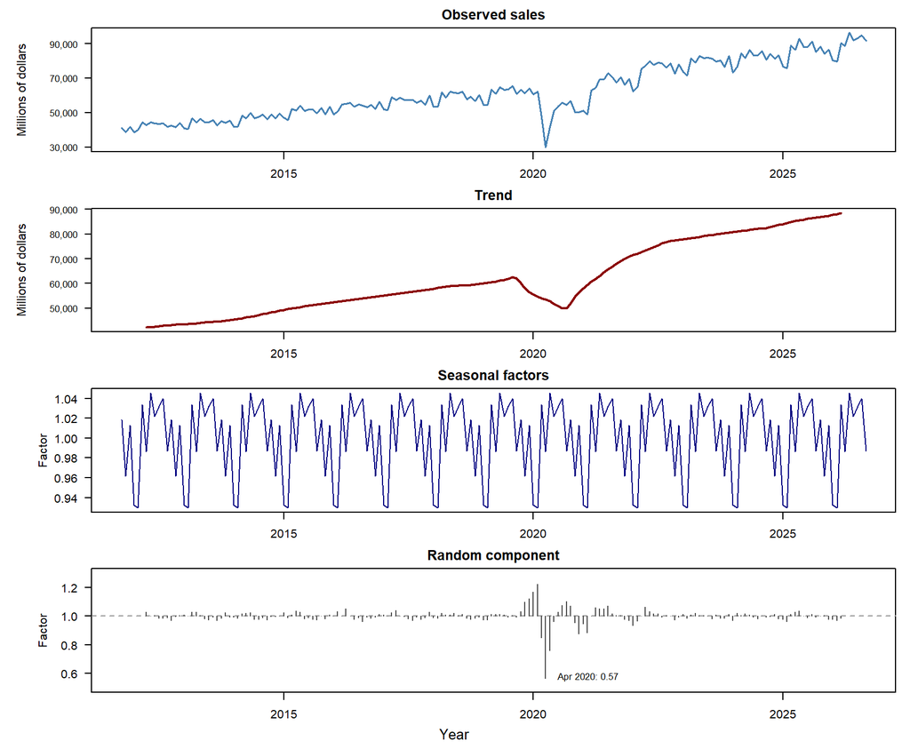

Figure 2. Classical multiplicative decomposition of monthly sales, October 2011 to September 2026. From top to bottom: the observed sales and the trend (millions of dollars), the seasonal factors (1 = an average month), and the random component (1 = no random error).

```r
# Time series object (12 months per year, starts October 2011)
sales.ts = ts(sales$sales, frequency = 12, start = c(2011, 10))
# Classical multiplicative decomposition of the 180 months
decomp.sales = decompose(sales.ts, type = "multiplicative")
# 4 panels: observed, trend, seasonal, random
par(mfrow = c(4, 1), mar = c(2, 6.5, 2, 1), oma = c(2, 0, 0, 0))
plot(sales.ts, col = "steelblue", lwd = 1.5, xlab = "", ylab = "", yaxt = "n",
     main = "Observed sales")
axis(2, at = seq(30000, 90000, 20000), las = 1, cex.axis = 0.8,
     labels = format(seq(30000, 90000, 20000), big.mark = ",", scientific = FALSE))
mtext("Millions of dollars", side = 2, line = 4.5, cex = 0.7)
plot(decomp.sales$trend, col = "darkred", lwd = 2, xlab = "", ylab = "", yaxt = "n",
     main = "Trend")
axis(2, at = seq(40000, 90000, 10000), las = 1, cex.axis = 0.8,
     labels = format(seq(40000, 90000, 10000), big.mark = ",", scientific = FALSE))
mtext("Millions of dollars", side = 2, line = 4.5, cex = 0.7)
plot(decomp.sales$seasonal, col = "navy", xlab = "", ylab = "Factor",
     main = "Seasonal factors", las = 1, cex.axis = 0.8)
plot(decomp.sales$random, type = "n", xlab = "", ylab = "Factor",
     main = "Random component", las = 1, cex.axis = 0.8, ylim = c(0.5, 1.3))
abline(h = 1, lty = 2, col = "gray60")
# Bars measured from 1 (no random error)
segments(time(decomp.sales$random), 1, time(decomp.sales$random), decomp.sales$random,
         col = "gray30")
# Label the random component in April 2020
r2020 = window(decomp.sales$random, start = c(2020, 4), end = c(2020, 4))
text(2020.35, 0.58, paste("Apr 2020:", round(r2020, 2)), pos = 4, cex = 0.8)
mtext("Year", side = 1, outer = TRUE, line = 0.5, cex = 0.8)
```

The trend shows a rise in sales, starting from about $42,000 million in 2012 to about $89,000 million in early 2026. In 2020, there was a large dip recorded. Furthermore, seasonal factors are highest in May and August, at about 1.04, whereas the lowest are found in January and February, at about 0.93, or about 7% below the trend. The random component fell to 0.57 in April 2020, meaning sales that month were about 43% below what the trend and the seasonal factor would give. Other than the months from December 2019 to February 2021, the value stayed close to 1.

We observe that the trend estimates for the first and last six months of the window are missing, which is a weakness of the classical method for forecasting. Since estimating the trend for a specific month requires a 12-month centered moving average, there are concerns about missing recent shifts in the trend’s direction.

## 3.4 Model Justification

The results above lead to the following choices for the forecasting model.

- **Log transformation:** Table 3 shows that the seasonal swings grow with the level of sales, so the series is multiplicative. Since $\log(y_t) = \log(T_t) + \log(S_t) + \log(E_t)$, taking the natural log turns it into an additive series, which the R function stl() requires.
- **STL decomposition with s.window = 12:** Seasonal and Trend decomposition using LOESS (STL) estimates the trend for every month, including the most recent six months that the classical method leaves out (Figure 2). Setting s.window = 12 lets the seasonal pattern change slowly over time, as Table 3 suggests it has.
- **Drift method:** Figure 1 shows an upward trend, so we forecast the seasonally adjusted series with the drift method, which continues the average change from the first to the last training month. The naive method would keep the forecasts flat at the last level. On the log scale, the drift is a constant percentage growth per month.

# 4 Forecasting with STL Decomposition

In this section, we split the data into training and testing data, decompose each training window with STL, forecast the 12 testing months with the drift method, and compare the forecasts with the actual values.

## 4.1 12-Month Testing Data and Three Training Windows

To evaluate the forecasts, we hold out the 12 most recent months (October 2025 to September 2026) as testing data since this period covers one full seasonal cycle. This allows every calendar month to be accounted for once. All three training windows end in September 2025, right before the testing data begins in October 2025. The only difference between the three lies in how far back the data extends. The 168-month training window provides a more historical view, dating back to 2011, whereas the 60-month window focuses on the most recent data. Considering the effects of COVID-19, we also include the 96-month window to capture the period before and after the 2020 drop without excessive older data. We use the 60-month window as our smallest window since it covers five complete seasonal cycles.

```r
# Testing data: the last 12 months (October 2025 to September 2026)
test.ts = window(sales.ts, start = c(2025, 10))
test.data = as.vector(test.ts)
# Training windows: 168, 96, and 60 months ending in September 2025
train168.ts = window(sales.ts, start = c(2011, 10), end = c(2025, 9))
train96.ts  = window(sales.ts, start = c(2017, 10), end = c(2025, 9))
train60.ts  = window(sales.ts, start = c(2020, 10), end = c(2025, 9))
# Summary table of the windows
window.table = data.frame(
  Window = c("168-month training", "96-month training", "60-month training", "Testing"),
  First = c("Oct 2011", "Oct 2017", "Oct 2020", "Oct 2025"),
  Last = c("Sep 2025", "Sep 2025", "Sep 2025", "Sep 2026"),
  Months = c(length(train168.ts), length(train96.ts), length(train60.ts), length(test.ts))
)
kable(window.table, col.names = c("Data", "First month", "Last month", "Months"),
      caption = "Table 4. Training windows and testing data.")
```

Table 4. Training windows and testing data.

| Data | First month | Last month | Months |
| --- | --- | --- | --- |
| 168-month training | Oct 2011 | Sep 2025 | 168 |
| 96-month training | Oct 2017 | Sep 2025 | 96 |
| 60-month training | Oct 2020 | Sep 2025 | 60 |
| Testing | Oct 2025 | Sep 2026 | 12 |

Table 4 shows that the three training windows contain 168, 96, and 60 months and share the same last month, September 2025, while the testing data contains the 12 months that follow.

## 4.2 Building the Forecasts

For each training window, we take the natural log of sales, decompose it with stl() using s.window = 12, and forecast the seasonally adjusted series with the drift method. The forecast for $h$ months after September 2025 is

$$\hat{y}_{T+h} = \exp\left(\hat{A}_T + h \cdot \frac{\hat{A}_T -
\hat{A}_1}{T-1} + \hat{S}_{T+h-12}\right)$$

where $\hat{A}_t$ is the seasonally adjusted log of sales (trend plus remainder), $T$ is the number of training months, and $\hat{S}_{T+h-12}$ is the seasonal component of the same calendar month in the last training year. The middle term includes $h$ times the drift, and exp() converts the forecast from the log scale back to millions of dollars.

```r
# STL decomposition of the log of each training window
stl168 = stl(log(train168.ts), s.window = 12)
stl96  = stl(log(train96.ts),  s.window = 12)
stl60  = stl(log(train60.ts),  s.window = 12)
# Forecast the 12 testing months with the drift method, then convert back to dollars
pred168 = exp(as.vector(forecast(stl168, h = 12, method = "rwdrift")$mean))
pred96  = exp(as.vector(forecast(stl96,  h = 12, method = "rwdrift")$mean))
pred60  = exp(as.vector(forecast(stl60,  h = 12, method = "rwdrift")$mean))
# Seasonally adjusted log sales (trend + remainder) and the drift of each window
sa168 = stl168$time.series[, "trend"] + stl168$time.series[, "remainder"]
sa96  = stl96$time.series[, "trend"]  + stl96$time.series[, "remainder"]
sa60  = stl60$time.series[, "trend"]  + stl60$time.series[, "remainder"]
# drift = (last - first) / (T - 1)
drift168 = (sa168[168] - sa168[1]) / (168 - 1)
drift96  = (sa96[96]   - sa96[1])  / (96 - 1)
drift60  = (sa60[60]   - sa60[1])  / (60 - 1)
```

Figure 3 shows the STL decomposition of the log of the 168-month training window as an example, since it covers all of the training history.

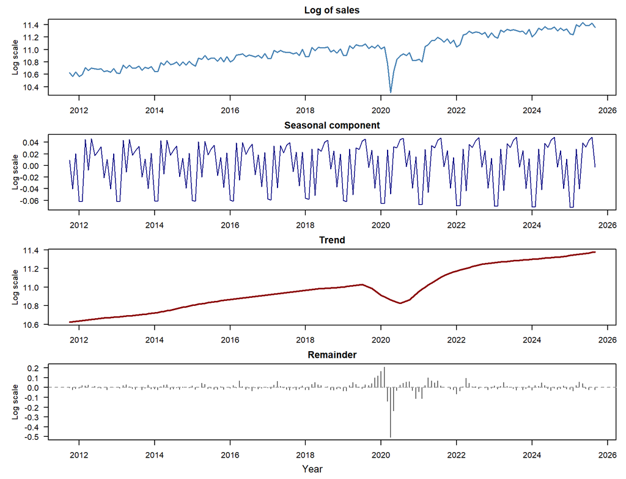

Figure 3. STL decomposition of the natural log of monthly sales for the 168-month training window (October 2011 to September 2025). From top to bottom: the log of sales, the seasonal component, the trend, and the remainder, all on the log scale.

```r
# Component panels for the 168-month window (log scale)
par(mfrow = c(4, 1), mar = c(2, 5, 2, 1), oma = c(2, 0, 0, 0))
plot(log(train168.ts), col = "steelblue", lwd = 1.5, xlab = "", ylab = "Log scale",
     main = "Log of sales", las = 1, cex.axis = 0.8)
plot(stl168$time.series[, "seasonal"], col = "navy", xlab = "", ylab = "Log scale",
     main = "Seasonal component", las = 1, cex.axis = 0.8)
plot(stl168$time.series[, "trend"], col = "darkred", lwd = 2, xlab = "", ylab = "Log scale",
     main = "Trend", las = 1, cex.axis = 0.8)
plot(stl168$time.series[, "remainder"], col = "gray30", type = "h", xlab = "", ylab = "Log scale",
     main = "Remainder", las = 1, cex.axis = 0.8)
abline(h = 0, lty = 2, col = "gray60")   # zero line
mtext("Year", side = 1, outer = TRUE, line = 0.5, cex = 0.8)
```

When assessing Figure 3, we see that the trend of the log of sales rises every year except for a dip around 2020. To allow for minor shifts in its shape, we use the setting s.window = 12 since the seasonal component is present annually. After removing trend and seasonality, the remainder typically stays close to zero. However, in April 2020, the remainder of −0.51 heavily deviated from zero, suggesting the trend and seasonality could not explain the sharp drop that month. Comparing the three training windows, we see that only the 60-month window excludes the April 2020 drop completely.

## 4.3 Forecasts and Actual Values

Table 5 lists the forecasts of the three training windows next to the actual sales of the 12 testing months.

```r
# Actual and forecasted sales of the 12 testing months
test.dates = seq(as.Date("2025-10-01"), as.Date("2026-09-01"), by = "month")
pred.table = data.frame(Month = format(test.dates, "%b %Y"),
                        Actual = test.data,
                        pred168 = pred168,
                        pred96 = pred96,
                        pred60 = pred60)
kable(pred.table, digits = 0, format.args = list(big.mark = ","),
      col.names = c("Month", "Actual", "168-month forecast", "96-month forecast", "60-month forecast"),
      caption = "Table 5. Actual and forecasted monthly sales (millions of dollars) for the 12 testing months.")
```

Table 5. Actual and forecasted monthly sales (millions of dollars) for the 12 testing months.

| Month | Actual | 168-month forecast | 96-month forecast | 60-month forecast |
| --- | --- | --- | --- | --- |
| Oct 2025 | 88,541 | 88,047 | 88,160 | 88,088 |
| Nov 2025 | 84,189 | 82,817 | 82,683 | 82,275 |
| Dec 2025 | 86,619 | 87,503 | 87,006 | 86,548 |
| Jan 2026 | 80,204 | 80,875 | 80,476 | 80,055 |
| Feb 2026 | 79,616 | 81,227 | 80,837 | 80,361 |
| Mar 2026 | 90,251 | 90,246 | 90,229 | 93,560 |
| Apr 2026 | 88,877 | 84,582 | 85,005 | 92,493 |
| May 2026 | 96,336 | 92,025 | 92,472 | 97,920 |
| Jun 2026 | 91,907 | 91,703 | 91,897 | 95,170 |
| Jul 2026 | 93,281 | 93,214 | 93,422 | 96,495 |
| Aug 2026 | 94,789 | 94,158 | 94,370 | 97,368 |
| Sep 2026 | 91,767 | 89,806 | 89,964 | 93,072 |

Upon evaluation, there is an alignment between the seasonal pattern of the three sets of forecasts and the actual sales: there are the typical lows in January and February, and the highs from May through August 2026. The 168-month and 96-month forecasts follow each other very closely, and both have their largest underestimations during April and May 2026—by about $3,900 million to $4,300 million—whereas the 60-month forecasts overestimate the actual sales in every month from February to September 2026.

Figure 4 shows the last 36 months of actual sales and the 12 forecasts from each training window.

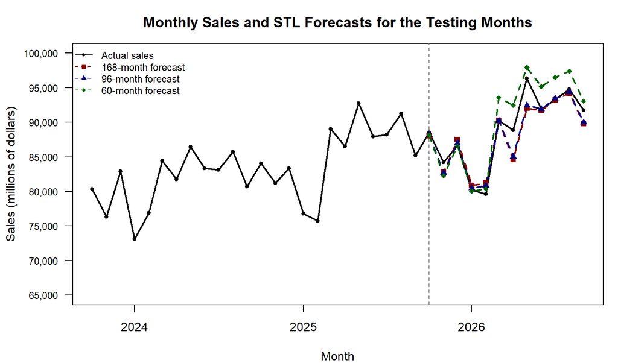

Figure 4. Monthly sales for the last 36 months (black, millions of dollars) and the forecasts of the three training windows for the 12 testing months (dashed lines). The vertical dashed line marks the start of the testing data.

```r
# Last 36 months of actual sales and the three sets of forecasts
recent = (n - 35):n
par(mar = c(4, 5, 3, 1))
plot(sales$date[recent], sales$sales[recent], type = "l", lwd = 2, yaxt = "n",
     ylim = c(65000, 100000), xlab = "Month", ylab = "",
     main = "Monthly Sales and STL Forecasts for the Testing Months")
points(sales$date[recent], sales$sales[recent], pch = 20)
axis(2, at = seq(65000, 100000, 5000), las = 1, cex.axis = 0.8,
     labels = format(seq(65000, 100000, 5000), big.mark = ","))
mtext("Sales (millions of dollars)", side = 2, line = 3.8)
# Dashed line at the first testing month
abline(v = test.dates[1], lty = 2, col = "gray50")
## forecasts of the three windows
lines(test.dates, pred168, lty = 2, lwd = 2, col = "darkred")
lines(test.dates, pred96, lty = 2, lwd = 2, col = "navy")
lines(test.dates, pred60, lty = 2, lwd = 2, col = "darkgreen")
points(test.dates, pred168, pch = 15, col = "darkred")
points(test.dates, pred96, pch = 17, col = "navy")
points(test.dates, pred60, pch = 18, col = "darkgreen")
legend("topleft", c("Actual sales", "168-month forecast", "96-month forecast", "60-month forecast"),
       col = c("black", "darkred", "navy", "darkgreen"), pch = c(20, 15, 17, 18),
       lty = c(1, 2, 2, 2), bty = "n", cex = 0.8)
```

Figure 4 illustrates how closely aligned the three forecasts are to the actual sales line. The two longer windows nearly overlap and, overall, stay closest to the observed sales. In the first four months of the test period, the 60-month forecasts stay close to the other two; however, from February 2026 onward, they shift above the actual sales line.

## 4.4 Accuracy Measures

We compare the windows with two accuracy measures, where $e_i = y_i - \hat{y}_i$ is the forecasting error of testing month $i$ in millions of dollars and $k = 12$. For both, a smaller value means more accurate forecasts.

- **Mean absolute percentage error (MAPE):** the average size of the errors as a percentage of the actual sales.

  $$\text{MAPE} = \frac{100}{k} \sum_{i=1}^{k} \left| \frac{e_i}{y_i}
  \right|$$
- **Mean squared error (MSE):** the average of the squared errors, in squared millions of dollars. Squaring gives more weight to large errors.

  $$\text{MSE} = \frac{1}{k} \sum_{i=1}^{k} e_i^2$$

Table 6 summarizes both measures along with the growth per month implied by each window’s drift.

```r
# Forecasting errors in millions of dollars
E168 = test.data - pred168
E96  = test.data - pred96
E60  = test.data - pred60
# MAPE (%): dividing by the actual sales
MAPE = 100 * c(mean(abs(E168 / test.data)), mean(abs(E96 / test.data)), mean(abs(E60 / test.data)))
# MSE
MSE = c(mean(E168^2), mean(E96^2), mean(E60^2))
# Monthly growth implied by the drift (%)
growth = 100 * (exp(c(drift168, drift96, drift60)) - 1)
accuracy = data.frame(Window = c("168 months", "96 months", "60 months"),
                      MAPE = MAPE, MSE = MSE, Growth = growth)
kable(accuracy, digits = c(0, 2, 0, 2), format.args = list(big.mark = ","),
      col.names = c("Training window", "MAPE (%)", "MSE (squared millions of dollars)",
                    "Drift: growth per month (%)"),
      caption = "Table 6. Accuracy measures of the STL forecasts on the 12 testing months (October 2025 to September 2026) and the monthly growth implied by each window's drift.")
```

Table 6. Accuracy measures of the STL forecasts on the 12 testing months (October 2025 to September 2026) and the monthly growth implied by each window’s drift.

| Training window | MAPE (%) | MSE (squared millions of dollars) | Drift: growth per month (%) |
| --- | --- | --- | --- |
| 168 months | 1.54 | 3,940,005 | 0.44 |
| 96 months | 1.29 | 3,124,759 | 0.46 |
| 60 months | 2.04 | 5,026,260 | 0.74 |

As shown in Table 6, the 96-month window produced the most accurate forecasts among the three windows for the 12 testing months, yielding the lowest MAPE (1.29%) and MSE (3,124,759). Ranking second on both measures was the 168-month window, with a MAPE of 1.54% and an MSE of 3,940,005. The 60-month window ranked last with the largest forecasting errors (MAPE = 2.04% and MSE = 5,026,260). When we compare the drift across the models, the 60-month window had the steepest projected growth per month (0.74%, compared with 0.44% for the 168-month window and 0.46% for the 96-month window). This is consistent with how drift is calculated, since it relies solely on the first and last training months. Specifically, the steeper trajectory reflects that the 60-month window began in October 2020 while sales were still recovering from the abrupt 2020 drop, causing its forecasts to grow faster than those of the other two windows, as shown in Figure 4.

## 4.5 Estimates of the Most Accurate Model

Table 7 reports the estimates of the 96-month model: its starting level, its drift, and the seasonal factors that build each forecast.

```r
# Estimates of the 96-month model: starting level, drift, and seasonal factors
# seasonal factors of the last training year, back from the log scale
season96 = exp(tail(as.vector(stl96$time.series[, "seasonal"]), 12))
final.table = data.frame(
  Estimate = c("Seasonally adjusted sales, September 2025 (millions of dollars)",
               "Drift (log scale)", "Growth per month (%)", "Growth per year (%)",
               paste("Seasonal factor,", format(test.dates, "%B"))),
  Value = c(format(round(exp(sa96[96])), big.mark = ","),
            format(round(drift96, 5), nsmall = 5),
            format(round(100 * (exp(drift96) - 1), 2), nsmall = 2),
            format(round(100 * (exp(12 * drift96) - 1), 2), nsmall = 2),
            format(round(season96, 3), nsmall = 3))
)
kable(final.table, align = c("l", "r"), col.names = c("Estimate", "Value"),
      caption = "Table 7. Estimates of the 96-month STL model. A seasonal factor of 1 means an average month; the factors come from the last training year (October 2024 to September 2025).")
```

Table 7. Estimates of the 96-month STL model. A seasonal factor of 1 means an average month; the factors come from the last training year (October 2024 to September 2025).

| Estimate | Value |
| --- | --- |
| Seasonally adjusted sales, September 2025 (millions of dollars) | 85,354 |
| Drift (log scale) | 0.00455 |
| Growth per month (%) | 0.46 |
| Growth per year (%) | 5.61 |
| Seasonal factor, October | 1.028 |
| Seasonal factor, November | 0.960 |
| Seasonal factor, December | 1.006 |
| Seasonal factor, January | 0.926 |
| Seasonal factor, February | 0.926 |
| Seasonal factor, March | 1.029 |
| Seasonal factor, April | 0.965 |
| Seasonal factor, May | 1.045 |
| Seasonal factor, June | 1.033 |
| Seasonal factor, July | 1.046 |
| Seasonal factor, August | 1.052 |
| Seasonal factor, September | 0.998 |

Starting from the fitted model’s September 2025 seasonally adjusted baseline ($85,354 million), the projected growth is about 0.46% per month, equivalent to about 5.61% per year. These figures are in current dollars, so this growth includes any price increases. Monthly seasonal factors then raise or lower each month’s level. These factors place January and February about 7.4% below their seasonally adjusted level. In contrast, they place August about 5.2% above it.

Overall, the STL forecasts across all three windows captured the testing year’s seasonal pattern. The window that delivered the most accurate forecasts in the 12 testing months was the 96-month window, followed by the 168-month window. On the other hand, the 60-month window, which started after the April 2020 drop, produced the largest errors of the three. As opposed to finding the best window across all time periods, the report focuses on comparing the three selected window sizes over these 12 testing months.

# 5 Results and Conclusions

This section summarizes the findings in plain language.

- **Best amount of history:** Using the last eight years of data (96 months) delivered the most accurate forecasts of monthly restaurant and bar sales from October 2025 to September 2026, with forecasts off by about 1.3% of the actual sales on average.
- **More data was not better here, and neither was less:** Using all 14 years of training data did not improve the forecasts (about 1.5% off) and may include older months that no longer reflect current sales, whereas using only the last five years (about 2.0% off) made the forecasts depend on a starting point shortly after the April 2020 drop.
- **Why the five-year window missed:** Since its starting point was during the recovery from the lowest sales month in the window, the five-year window expected faster growth, and its forecasts were too high from February to September 2026.
- **The yearly pattern was captured:** All three forecasts expected the slowest months in January and February and the busiest months from May to August.

# 6 General Discussion

This section will interpret the findings in relation to the research question and cover how we can use the information, the limitations, and future improvements.

## 6.1 Answering the Research Question

In conclusion, the accuracy measures indicated that of the three training windows, the 96-month window (October 2017 to September 2025) delivered the most accurate STL forecasts of monthly U.S. restaurant and bar sales for the 12 testing months. Specifically, it had the smallest MAPE (1.29%) and MSE, followed by the 168-month window, and finally the 60-month window. Note that a different testing year could yield different accuracy results.

## 6.2 Recommendations

These results could be used by restaurant owners, suppliers, and analysts who forecast monthly sales for the next year.

- **Use about eight years of history:** For these 12 testing months, the 96-month window was more accurate than both the longest and shortest windows covered in this report.
- **Be cautious of abrupt changes:** With a window size of 60 months, the training data began shortly after the April 2020 drop at the start of COVID-19. At that point, sales were still recovering from their largest fall in the past 15 years, which made the drift steeper and led to forecasts above the actual sales from February to September 2026. These results suggest that a training window should not start during a disruption.
- **Plan around the seasonal pattern:** Planning can be adjusted using the 96-month model, for the months that deviate from the seasonally adjusted level. These months are January and February, when sales are estimated to be about 7% below that level, and August, when they are estimated to be about 5% above it (Table 7).

## 6.3 Limitations

The following limitations should be kept in mind when using these results.

1. **The 2020 drop:** Both longer training windows (96 and 168 months) include the April 2020 drop, and all three (60, 96, and 168 months) include the winter 2020–21 dip, so each is affected by abrupt changes in the pattern.
2. **Drift uses two months:** Because the drift method uses only the first and last training months, the starting and ending points matter, as abrupt changes at those points can heavily influence the steepness of the drift and move it away from the actual long-run growth.
3. **Inflation:** Since sales are in current dollars, part of the growth may be attributed to an increase in prices.
4. **Preliminary data:** September 2026 is an initial estimate and may be revised.
5. **Calendar effects:** The number of days and weekends in each month changes from year to year, and the model does not account for this.
6. **Back-transformation:** The log forecasts were converted back with exp() without a bias adjustment, so the forecasts may run slightly low.
7. **What the results show:** The results show which window was most accurate for the 12 testing months, not the real-world reasons behind the sales pattern. Possible explanations, such as stimulus payments or changes in takeout habits after 2020, were not tested.

## 6.4 Future Improvements

Moving forward, future analyses could search for the training window that gives the most accurate forecasts for a business’s planning needs. Furthermore, we may implement a model that controls for abrupt changes such as the April 2020 drop, which may benefit the longer windows that include it. Finally, since the series uses current dollars, it is unclear whether the rise in sales stems from more demand or from higher prices. Adjusting the data for inflation can separate the two, which may assist supply and staffing readiness.

# 7 References

Federal Reserve Bank of St. Louis. (2026). *Retail sales: Food services and drinking places (MRTSSM722USN)* [Data set]. U.S. Census Bureau, retrieved from FRED. Retrieved November 17, 2026, from https://fred.stlouisfed.org/series/MRTSSM722USN

U.S. Census Bureau. (2026). *Monthly Retail Trade Survey: About the survey*. Retrieved November 17, 2026, from https://www.census.gov/retail/mrts/about_the_surveys.html